# Lecture 3: Data Visualization in R

September, 2015

## Graphs in R

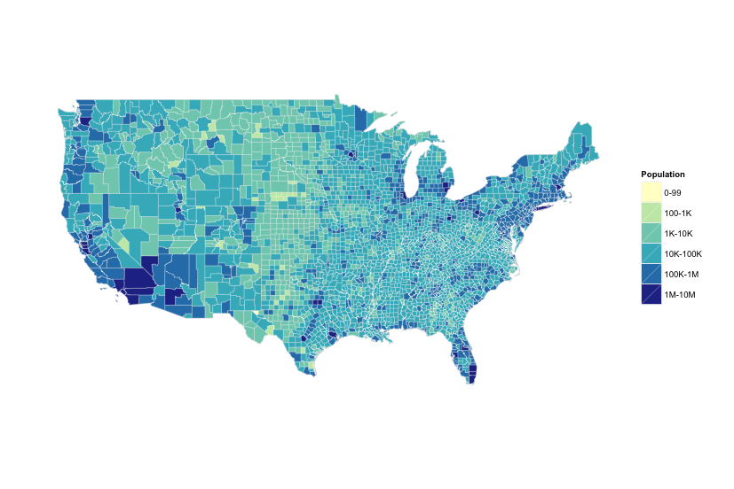

source: [Bob Rudis](https://github.com/hrbrmstr?tab=repositories)

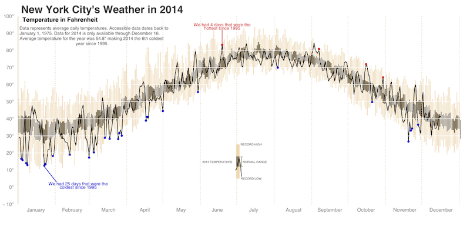

source: [Alex Bresler](https://gist.github.com/abresler/46c36c1a88c849b94b07)

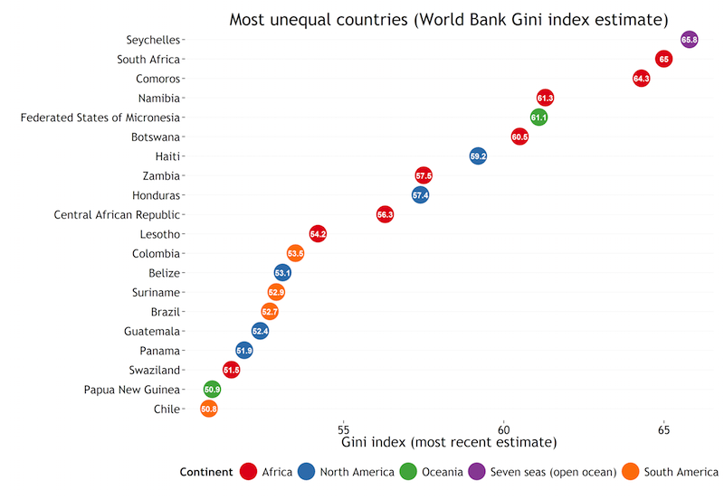

source: [Kyle Walker](http://walkerke.github.io/2015/04/map-or-chart/)

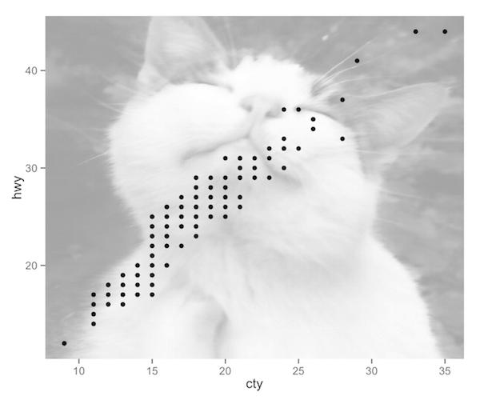

source: [Hillary Parker](https://github.com/hilaryparker/cats)

**Grammar of Graphics**

> A statistical graph is a mapping from *data* to *aesthetic* attributes (colour, shape, size) of *geometric* objects (points, lines, bars). The plot may also contain *statistical transformations* of the data and is drawn on a specific *coordinate* system. *Faceting* can be used to generate the same plot for different subsets of the dataset. It is the combination of these independent components that make up a graphic.  
> - Wickham, *ggplot2*, p. 3.

## Components of a graph

- **data**: What you want to visualize, including variables (columns) to be mapped to aesthetic attributes.
- **geom**: Geometric objects that are drawn to represent the data: bars, lines, points, etc.
- **stats**: Statistical transformations of the data, such as binning or averaging.
- **scales**: Map values in the data space to values in an aesthetic space (color, shape, size…)
- **coord**: Coordinate system; provides axes and gridlines to make it possible to read the graph.
- **facets**: Breaking up the data into subsets, to be displayed independently on a grid.